# Advertising Analysis

## Defining the Question

A Kenyan entrepreneur has created an online cryptography course and would want to advertise it on her blog. She currently targets audiences originating from various countries. In the past, she ran ads to advertise a related course on the same blog and collected data in the process. She would now like to employ your services as a Data Science Consultant to help her identify which individuals are most likely to click on her ads.

### a)Specifying the Question

1. Identify which Individuals are most likely to click on the client’s Ads

### b)The metric of Success

Identify which Individuals are most likely to click on the ads based on the data acquired

### c)The Context

Online marketing of a Cryptography Class by using Ads

### d)Experimental Design

1. Load Data
2. Check the Data
3. Tidy the Data
4. Analyze the Data

## Reading the Data

```r
# plotting libraries
library("dplyr")
library("ggplot2")
```

```r
# Load the dataset
advertising <- read.csv("~/Documents/R markdowns/advertising.csv")
head(advertising)
```

```
##   Daily.Time.Spent.on.Site Age Area.Income Daily.Internet.Usage
## 1                    68.95  35    61833.90               256.09
## 2                    80.23  31    68441.85               193.77
## 3                    69.47  26    59785.94               236.50
## 4                    74.15  29    54806.18               245.89
## 5                    68.37  35    73889.99               225.58
## 6                    59.99  23    59761.56               226.74
##                           Ad.Topic.Line           City Male    Country
## 1    Cloned 5thgeneration orchestration    Wrightburgh    0    Tunisia
## 2    Monitored national standardization      West Jodi    1      Nauru
## 3      Organic bottom-line service-desk       Davidton    0 San Marino
## 4 Triple-buffered reciprocal time-frame West Terrifurt    1      Italy
## 5         Robust logistical utilization   South Manuel    0    Iceland
## 6       Sharable client-driven software      Jamieberg    1     Norway
##             Timestamp Clicked.on.Ad
## 1 2016-03-27 00:53:11             0
## 2 2016-04-04 01:39:02             0
## 3 2016-03-13 20:35:42             0
## 4 2016-01-10 02:31:19             0
## 5 2016-06-03 03:36:18             0
## 6 2016-05-19 14:30:17             0
```

## Checking the Data

```r
# The shape of the dataset
dim(advertising)
```

```
## [1] 1000   10
```

```r
# The Data Types of
str(advertising)
```

```
## 'data.frame':    1000 obs. of  10 variables:
##  $ Daily.Time.Spent.on.Site: num  69 80.2 69.5 74.2 68.4 ...
##  $ Age                     : int  35 31 26 29 35 23 33 48 30 20 ...
##  $ Area.Income             : num  61834 68442 59786 54806 73890 ...
##  $ Daily.Internet.Usage    : num  256 194 236 246 226 ...
##  $ Ad.Topic.Line           : Factor w/ 1000 levels "Adaptive 24hour Graphic Interface",..: 92 465 567 904 767 806 223 724 108 455 ...
##  $ City                    : Factor w/ 969 levels "Adamsbury","Adamside",..: 962 904 112 940 806 283 47 672 885 713 ...
##  $ Male                    : int  0 1 0 1 0 1 0 1 1 1 ...
##  $ Country                 : Factor w/ 237 levels "Afghanistan",..: 216 148 185 104 97 159 146 13 83 79 ...
##  $ Timestamp               : Factor w/ 1000 levels "2016-01-01 02:52:10",..: 440 475 368 57 768 690 131 334 549 942 ...
##  $ Clicked.on.Ad           : int  0 0 0 0 0 0 0 1 0 0 ...
```

## Tidying the Data

```r
#Missing Data
colSums(is.na(advertising))
```

```
## Daily.Time.Spent.on.Site                      Age              Area.Income
##                        0                        0                        0
##     Daily.Internet.Usage            Ad.Topic.Line                     City
##                        0                        0                        0
##                     Male                  Country                Timestamp
##                        0                        0                        0
##            Clicked.on.Ad
##                        0
```

```r
# No missing values
```

```r
#Duplicated Values
advert <- unique(advertising)
dim(advert)
```

```
## [1] 1000   10
```

```r
# No duplicated values
```

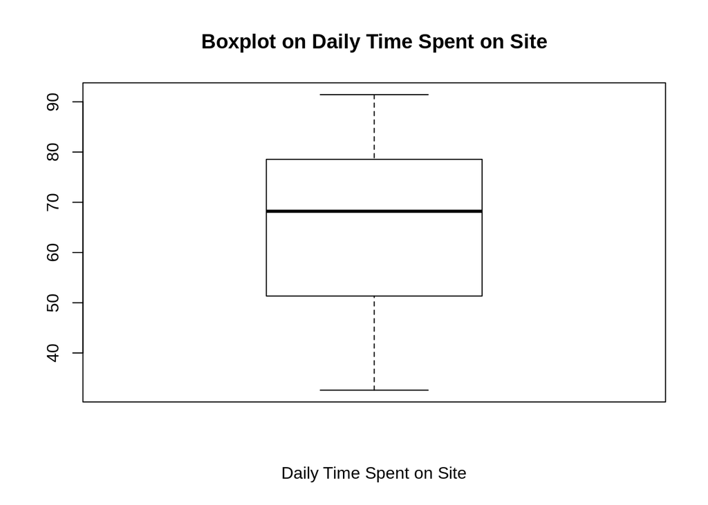

```r
#Outliers

boxplot(advert$Daily.Time.Spent.on.Site,xlab="Daily Time Spent on Site",main="Boxplot on Daily Time Spent on Site")
```

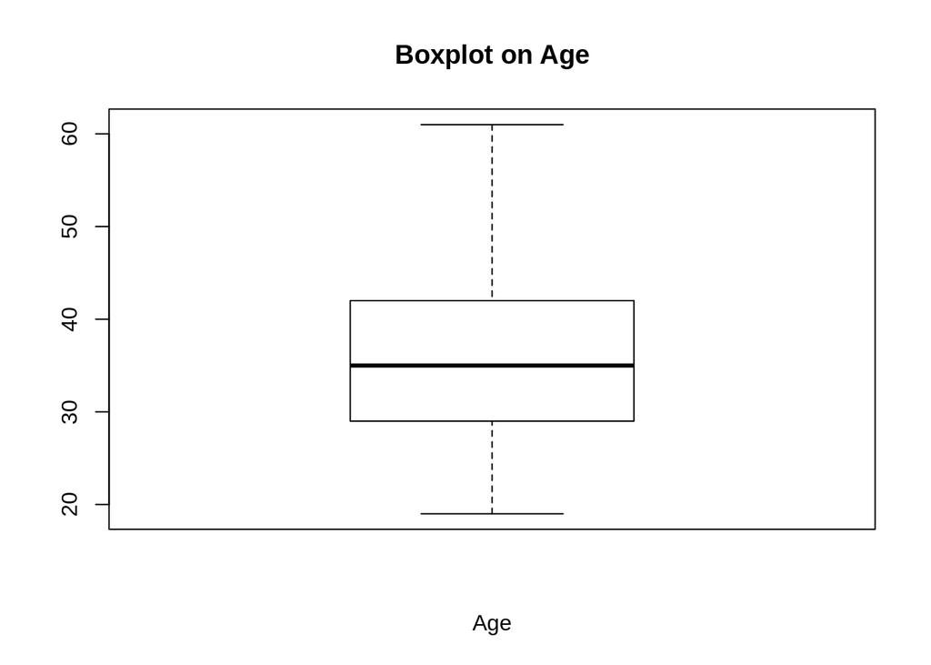

```r
boxplot(advert$Age, xlab="Age",main="Boxplot on Age")
```

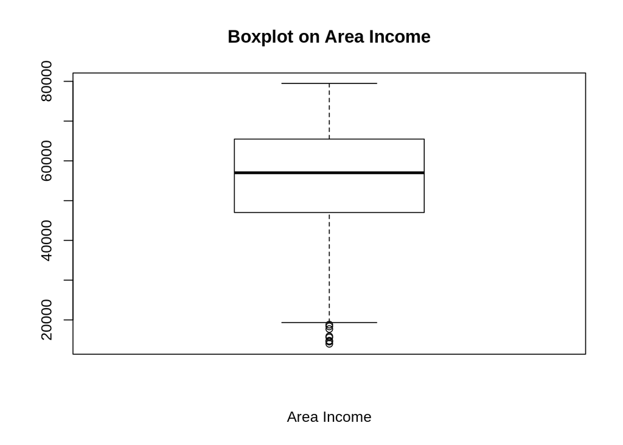

```r
boxplot(advert$Area.Income,xlab="Area Income",main="Boxplot on Area Income")
```

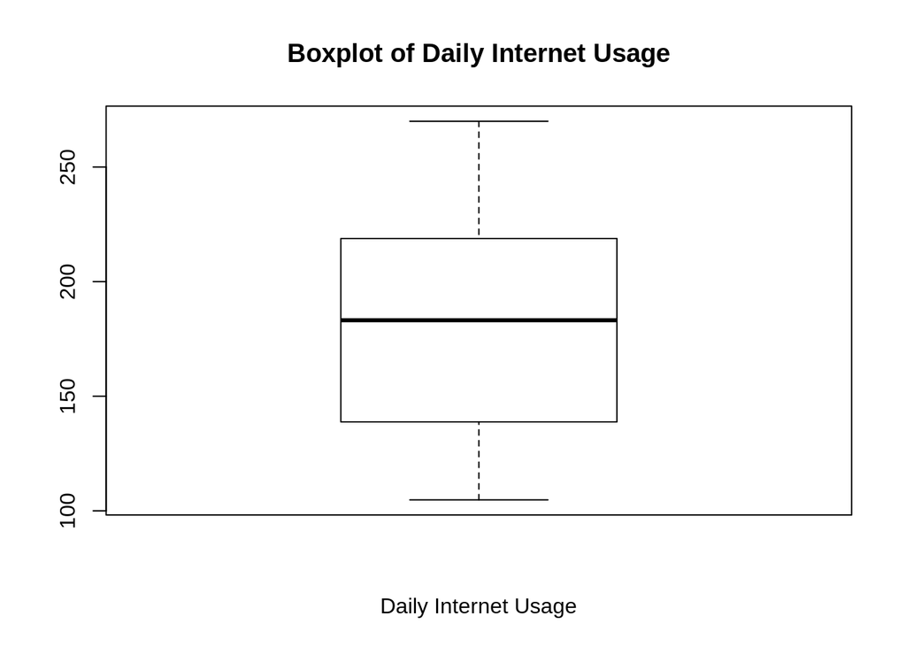

```r
boxplot(advert$Daily.Internet.Usage, xlab="Daily Internet Usage", main="Boxplot of Daily Internet Usage")
```

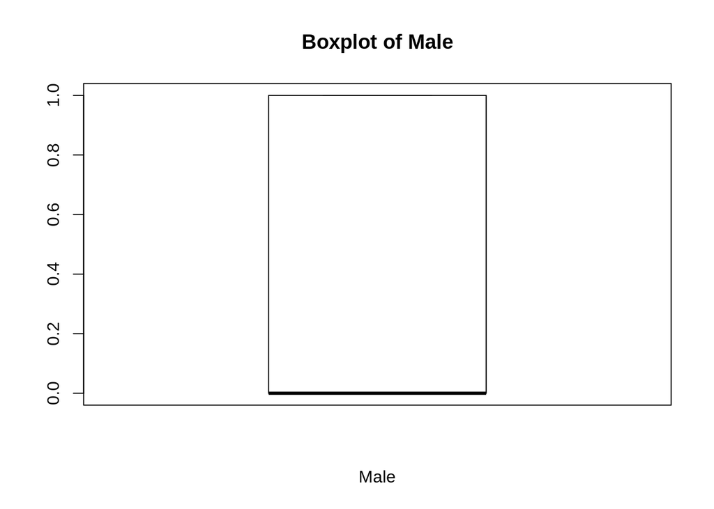

```r
boxplot(advert$Male, xlab="Male", main="Boxplot of Male")
```

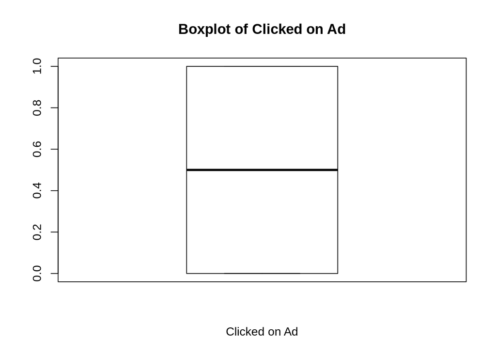

```r
boxplot(advert$Clicked.on.Ad, xlab="Clicked on Ad", main="Boxplot of Clicked on Ad")
```

```r
# The number of outliers
boxplot.stats(advert$Area.Income)$out
```

```
## [1] 17709.98 18819.34 15598.29 15879.10 14548.06 13996.50 14775.50 18368.57
```

```r
sum(table(boxplot.stats(advert$Area.Income)$out))
```

```
## [1] 8
```

Outliers were not removed to see their role in the analysis

## Exploratory Data Analysis

### Univariate

#### Numeric Columns

```r
#Numeric Values
num = advert[,c(1,2,3,4,7,10)]
summary(num)
```

```
##  Daily.Time.Spent.on.Site      Age         Area.Income    Daily.Internet.Usage
##  Min.   :32.60            Min.   :19.00   Min.   :13996   Min.   :104.8
##  1st Qu.:51.36            1st Qu.:29.00   1st Qu.:47032   1st Qu.:138.8
##  Median :68.22            Median :35.00   Median :57012   Median :183.1
##  Mean   :65.00            Mean   :36.01   Mean   :55000   Mean   :180.0
##  3rd Qu.:78.55            3rd Qu.:42.00   3rd Qu.:65471   3rd Qu.:218.8
##  Max.   :91.43            Max.   :61.00   Max.   :79485   Max.   :270.0
##       Male       Clicked.on.Ad
##  Min.   :0.000   Min.   :0.0
##  1st Qu.:0.000   1st Qu.:0.0
##  Median :0.000   Median :0.5
##  Mean   :0.481   Mean   :0.5
##  3rd Qu.:1.000   3rd Qu.:1.0
##  Max.   :1.000   Max.   :1.0
```

```r
#Mean
paste("Mean for Daily Time Spent on Site:")
```

```
## [1] "Mean for Daily Time Spent on Site:"
```

```r
mean(advert$Daily.Time.Spent.on.Site)
```

```
## [1] 65.0002
```

```r
paste("Mean for Age:")
```

```
## [1] "Mean for Age:"
```

```r
mean(advert$Age)
```

```
## [1] 36.009
```

```r
paste("Mean for Area Income:")
```

```
## [1] "Mean for Area Income:"
```

```r
mean(advert$Area.Income)
```

```
## [1] 55000
```

```r
paste("Mean for Daily Internet Usage:")
```

```
## [1] "Mean for Daily Internet Usage:"
```

```r
mean(advert$Daily.Internet.Usage)
```

```
## [1] 180.0001
```

```r
paste("Mean for Male:")
```

```
## [1] "Mean for Male:"
```

```r
mean(advert$Male)
```

```
## [1] 0.481
```

```r
paste("Mean for Cliked on Ad:")
```

```
## [1] "Mean for Cliked on Ad:"
```

```r
mean(advert$Clicked.on.Ad)
```

```
## [1] 0.5
```

```r
# Median
paste("Median for Daily Time Spent on Site:")
```

```
## [1] "Median for Daily Time Spent on Site:"
```

```r
median(advert$Daily.Time.Spent.on.Site)
```

```
## [1] 68.215
```

```r
paste("Median for Age:")
```

```
## [1] "Median for Age:"
```

```r
median(advert$Age)
```

```
## [1] 35
```

```r
paste("Median for Area Income:")
```

```
## [1] "Median for Area Income:"
```

```r
median(advert$Area.Income)
```

```
## [1] 57012.3
```

```r
paste("Median for Daily Internet Usage:")
```

```
## [1] "Median for Daily Internet Usage:"
```

```r
median(advert$Daily.Internet.Usage)
```

```
## [1] 183.13
```

```r
paste("Median for Male:")
```

```
## [1] "Median for Male:"
```

```r
median(advert$Male)
```

```
## [1] 0
```

```r
paste("Median for Cliked on Ad:")
```

```
## [1] "Median for Cliked on Ad:"
```

```r
median(advert$Clicked.on.Ad)
```

```
## [1] 0.5
```

```r
# Mode
getMode <- function(v){
  uniqv <- unique(v)
  uniqv[which.max(tabulate(match(v, uniqv)))]
}
paste("Mode for Daily Time Spent on Site:")
```

```
## [1] "Mode for Daily Time Spent on Site:"
```

```r
getMode(advert$Daily.Time.Spent.on.Site)
```

```
## [1] 62.26
```

```r
paste("Mode for Age:")
```

```
## [1] "Mode for Age:"
```

```r
getMode(advert$Age)
```

```
## [1] 31
```

```r
paste("Mode for Area Income:")
```

```
## [1] "Mode for Area Income:"
```

```r
getMode(advert$Area.Income)
```

```
## [1] 61833.9
```

```r
paste("Mode for Daily Internet Usage:")
```

```
## [1] "Mode for Daily Internet Usage:"
```

```r
getMode(advert$Daily.Internet.Usage)
```

```
## [1] 167.22
```

```r
paste("Mode for Male:")
```

```
## [1] "Mode for Male:"
```

```r
getMode(advert$Male)
```

```
## [1] 0
```

```r
paste("Mode for Clicked on Ad")
```

```
## [1] "Mode for Clicked on Ad"
```

```r
getMode(advert$Clicked.on.Ad)
```

```
## [1] 0
```

```r
#Variance
paste("Variance for Daily Time Spent on Site:")
```

```
## [1] "Variance for Daily Time Spent on Site:"
```

```r
var(advert$Daily.Time.Spent.on.Site)
```

```
## [1] 251.3371
```

```r
paste("Variance for Age:")
```

```
## [1] "Variance for Age:"
```

```r
var(advert$Age)
```

```
## [1] 77.18611
```

```r
paste("Variance for Area Income:")
```

```
## [1] "Variance for Area Income:"
```

```r
var(advert$Area.Income)
```

```
## [1] 179952406
```

```r
paste("Variance for Daily Internet Usage:")
```

```
## [1] "Variance for Daily Internet Usage:"
```

```r
var(advert$Daily.Internet.Usage)
```

```
## [1] 1927.415
```

```r
paste("Variance for Male:")
```

```
## [1] "Variance for Male:"
```

```r
var(advert$Male)
```

```
## [1] 0.2498889
```

```r
paste("Variance for Clicked on Ad:")
```

```
## [1] "Variance for Clicked on Ad:"
```

```r
var(advert$Clicked.on.Ad)
```

```
## [1] 0.2502503
```

```r
# Standard Deviation
paste("Standard Deviation for Daily Time Spent on Site:")
```

```
## [1] "Standard Deviation for Daily Time Spent on Site:"
```

```r
sd(advert$Daily.Time.Spent.on.Site)
```

```
## [1] 15.85361
```

```r
paste("Standard Deviation for Age:")
```

```
## [1] "Standard Deviation for Age:"
```

```r
sd(advert$Age)
```

```
## [1] 8.785562
```

```r
paste("Standard Deviation for Area Income:")
```

```
## [1] "Standard Deviation for Area Income:"
```

```r
sd(advert$Area.Income)
```

```
## [1] 13414.63
```

```r
paste("Standard Deviation for Daily Internet Usage:")
```

```
## [1] "Standard Deviation for Daily Internet Usage:"
```

```r
sd(advert$Daily.Internet.Usage)
```

```
## [1] 43.90234
```

```r
paste("Standard Deviation for Male:")
```

```
## [1] "Standard Deviation for Male:"
```

```r
sd(advert$Male)
```

```
## [1] 0.4998889
```

```r
paste("Standard Deviation for Clicked on Ad:")
```

```
## [1] "Standard Deviation for Clicked on Ad:"
```

```r
sd(advert$Clicked.on.Ad)
```

```
## [1] 0.5002502
```

```r
# Quantiles
paste("Quantiles for Daily Time Spent on Site:")
```

```
## [1] "Quantiles for Daily Time Spent on Site:"
```

```r
quantile(advert$Daily.Time.Spent.on.Site)
```

```
##      0%     25%     50%     75%    100%
## 32.6000 51.3600 68.2150 78.5475 91.4300
```

```r
paste("Quantiles for Age:")
```

```
## [1] "Quantiles for Age:"
```

```r
quantile(advert$Age)
```

```
##   0%  25%  50%  75% 100%
##   19   29   35   42   61
```

```r
paste("Quantiles for Area Income:")
```

```
## [1] "Quantiles for Area Income:"
```

```r
quantile(advert$Area.Income)
```

```
##       0%      25%      50%      75%     100%
## 13996.50 47031.80 57012.30 65470.64 79484.80
```

```r
paste("Quantiles for Daily Internet Usage:")
```

```
## [1] "Quantiles for Daily Internet Usage:"
```

```r
quantile(advert$Daily.Internet.Usage)
```

```
##       0%      25%      50%      75%     100%
## 104.7800 138.8300 183.1300 218.7925 269.9600
```

```r
paste("Quantiles for Male:")
```

```
## [1] "Quantiles for Male:"
```

```r
quantile(advert$Male)
```

```
##   0%  25%  50%  75% 100%
##    0    0    0    1    1
```

```r
paste("Quantiles for Clicked on Ad:")
```

```
## [1] "Quantiles for Clicked on Ad:"
```

```r
quantile(advert$Clicked.on.Ad)
```

```
##   0%  25%  50%  75% 100%
##  0.0  0.0  0.5  1.0  1.0
```

#### Histogram

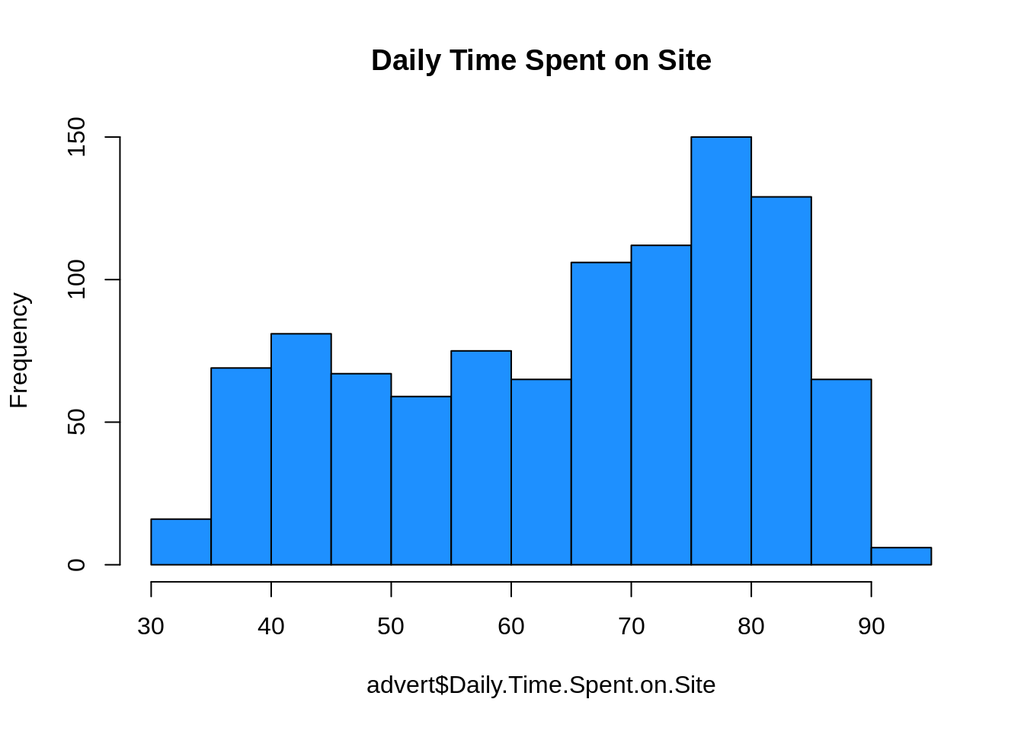

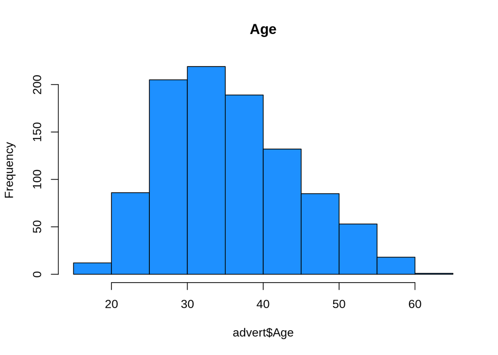

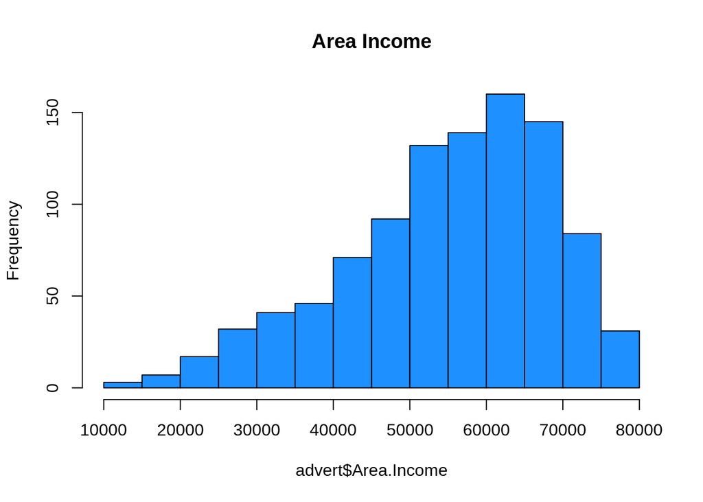

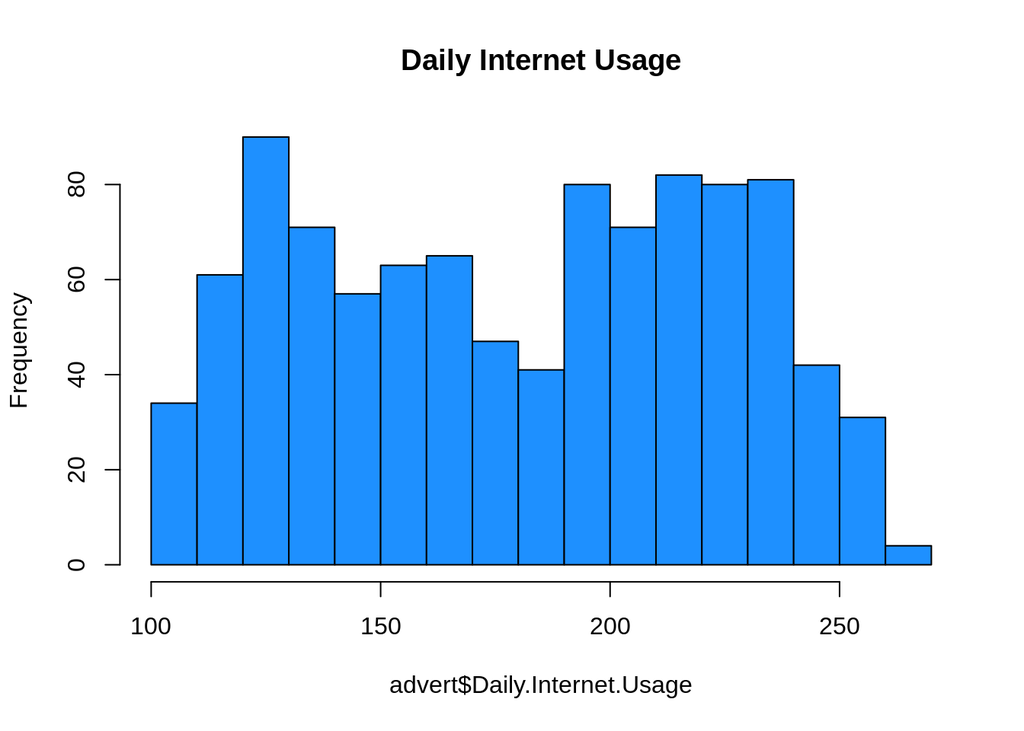

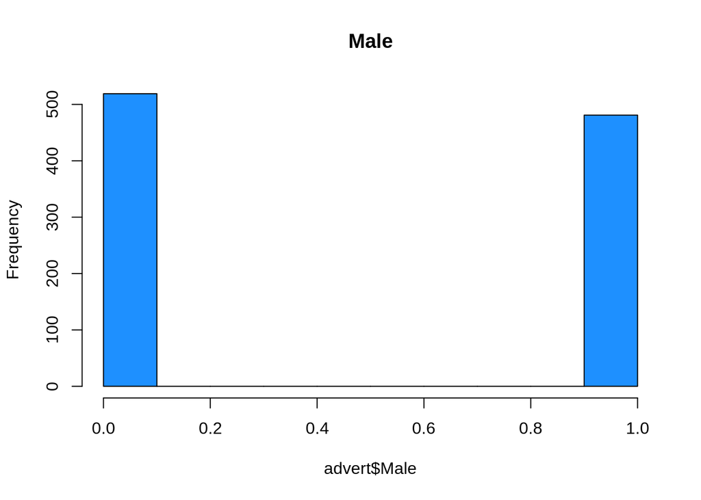

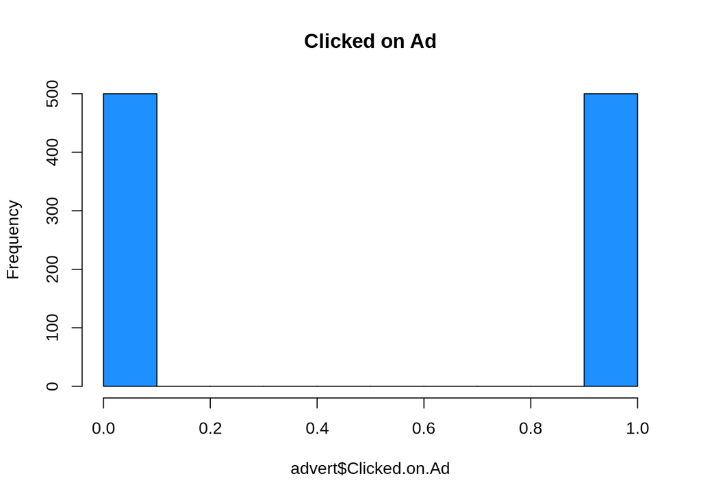

From the Male and the Clicked on Ad are categorical in nature

The Most frequent age is between approximately 25years and 40 years

#### BarPlots

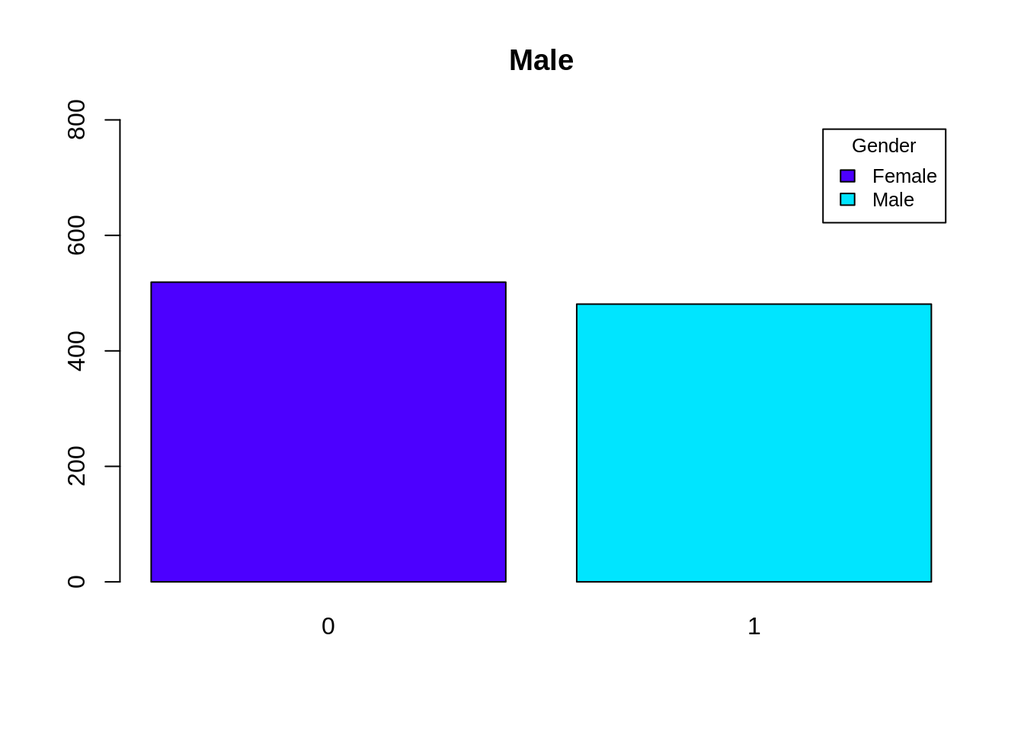

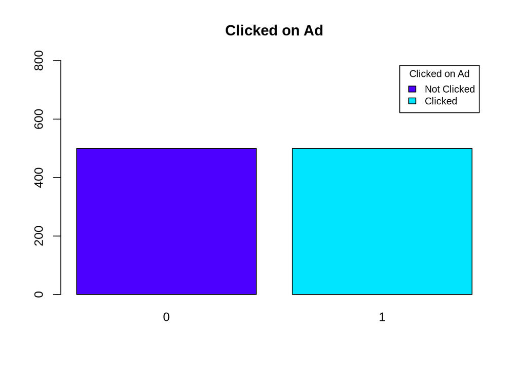

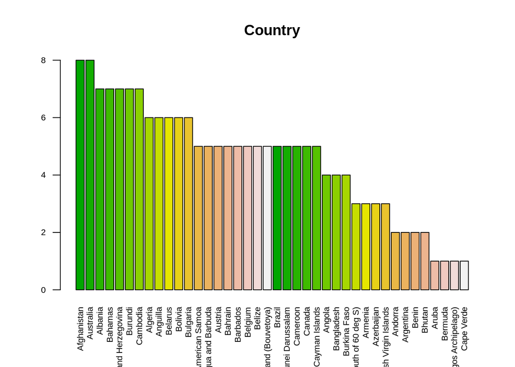

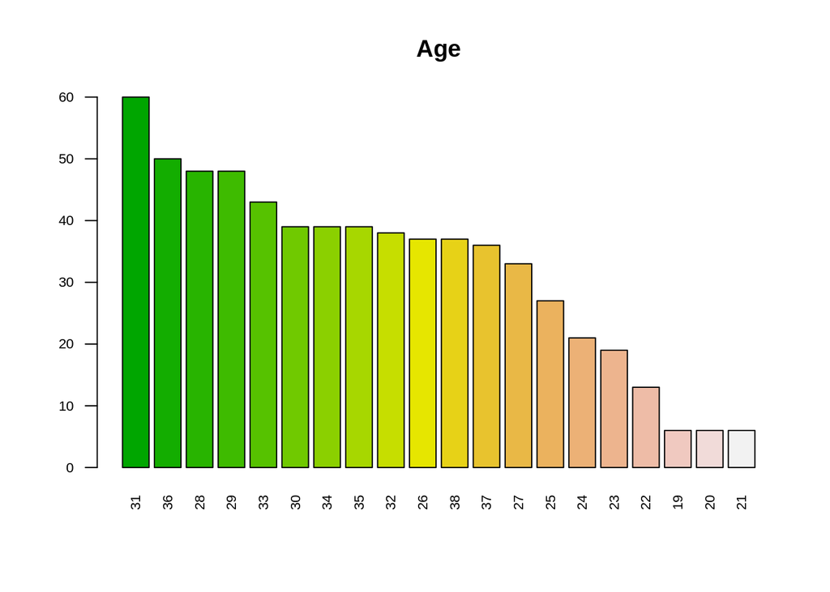

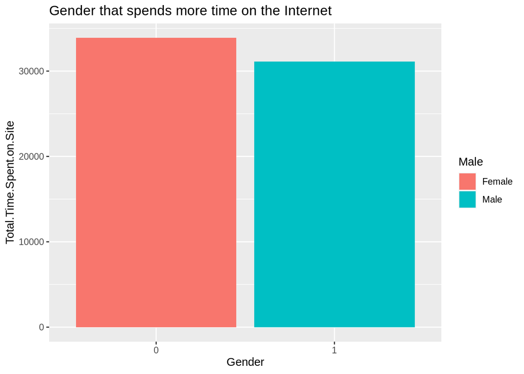

```
## # A tibble: 20 x 2
##    Country                                      clicked.ad
##    <fct>                                             <int>
##  1 Afghanistan                                           5
##  2 Albania                                               4
##  3 Algeria                                               3
##  4 American Samoa                                        3
##  5 Andorra                                               2
##  6 Angola                                                1
##  7 Anguilla                                              3
##  8 Antarctica (the territory South of 60 deg S)          2
##  9 Antigua and Barbuda                                   4
## 10 Argentina                                             1
## 11 Armenia                                               1
## 12 Aruba                                                 0
## 13 Australia                                             7
## 14 Austria                                               1
## 15 Azerbaijan                                            1
## 16 Bahamas                                               4
## 17 Bahrain                                               2
## 18 Bangladesh                                            2
## 19 Barbados                                              2
## 20 Belarus                                               3
```

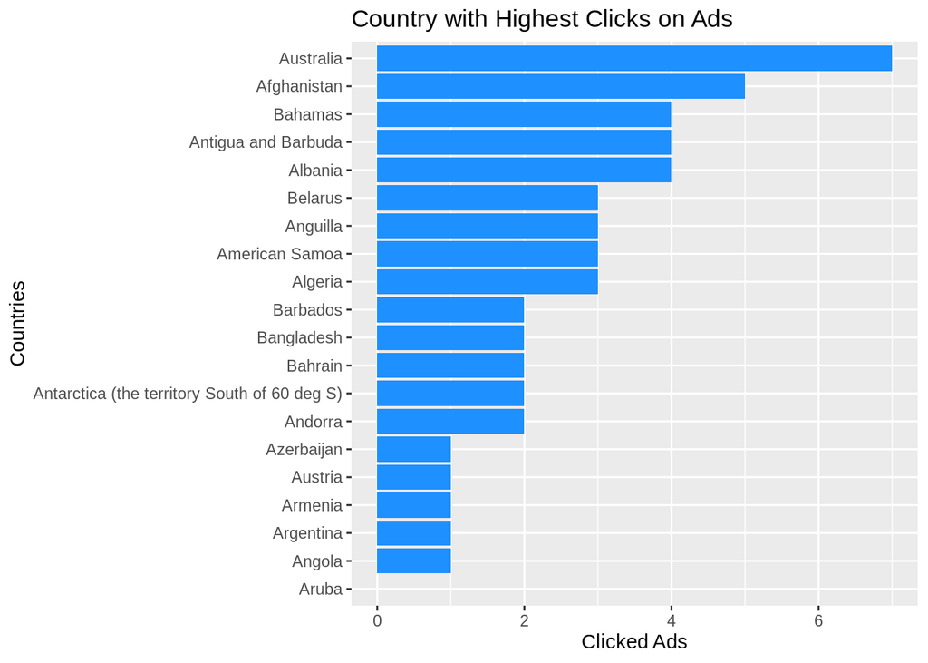

```
## # A tibble: 2 x 2
##   Clicked.on.Ad gender
##           <int>  <int>
## 1             0    250
## 2             1    269
```

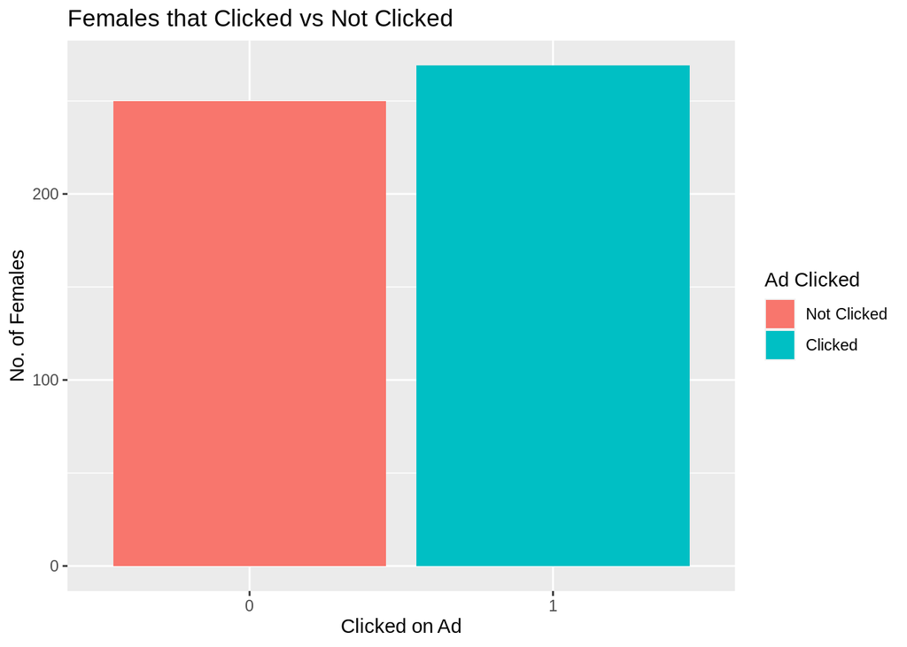

```
## # A tibble: 2 x 2
##   Clicked.on.Ad gender
##           <int>  <int>
## 1             0    250
## 2             1    231
```

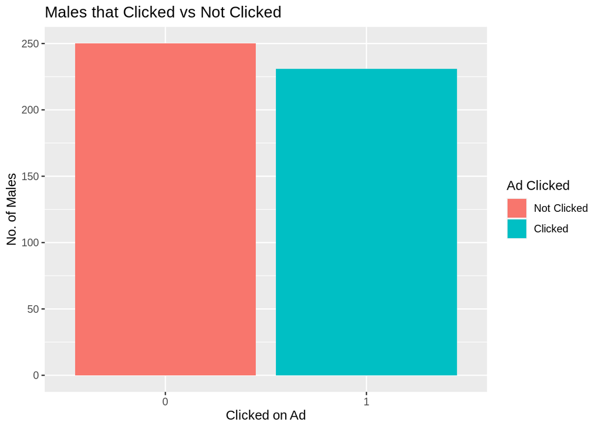

```r
# Ad topic Line
value.count <- table(advert$Ad.Topic.Line)
head(value.count)
```

```
##
##       Adaptive 24hour Graphic Interface          Adaptive asynchronous attitude
##                                       1                                       1
##  Adaptive context-sensitive application Adaptive contextually-based methodology
##                                       1                                       1
##    Adaptive demand-driven knowledgebase             Adaptive uniform capability
##                                       1                                       1
```

```r
sum(value.count)
```

```
## [1] 1000
```

```r
# Only one occurrence of every topic line
```

From the Male column, 0 means Female and 1 means Male, we have more Females than Males In the Clicked on Ad column, number of clicked versus not clicked are equal

The most popular countries are Afghanistan, Australia, Albania, Bahamas are the top 4 countries The most popular age is 31 years Females spend more time in the Internet compared to Males and with more Females spending time on the Internet, we see that most of them click on Ads compared to Males

But there is still a significant number of Females who don’t click on Ads.

The Countries that had the highest number in clicked ads was Australia, Afghanistan and Bahamas

The Ad Topic Line are there is only one occurrence of each.

### Bivariate

#### Covariance

```r
numeric_col <- advert[,c(1,2,3,4,7,10)]
head(numeric_col,4)
```

```
##   Daily.Time.Spent.on.Site Age Area.Income Daily.Internet.Usage Male
## 1                    68.95  35    61833.90               256.09    0
## 2                    80.23  31    68441.85               193.77    1
## 3                    69.47  26    59785.94               236.50    0
## 4                    74.15  29    54806.18               245.89    1
##   Clicked.on.Ad
## 1             0
## 2             0
## 3             0
## 4             0
```

```r
# Covariance
covariance_matrix = cov(numeric_col)
View(round(covariance_matrix,2))
```

#### Correlation

```r
# Correlation Matrix
correlation_matrix = cor(numeric_col)
View(round(correlation_matrix,2))
```

#### Scatter Plots

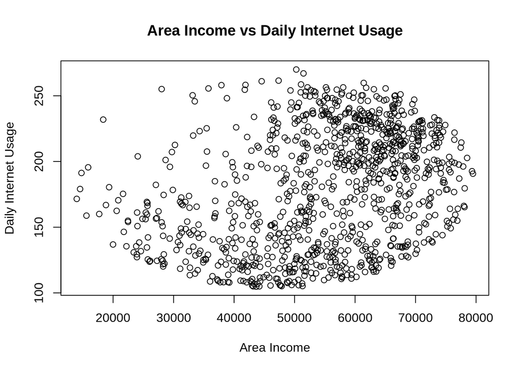

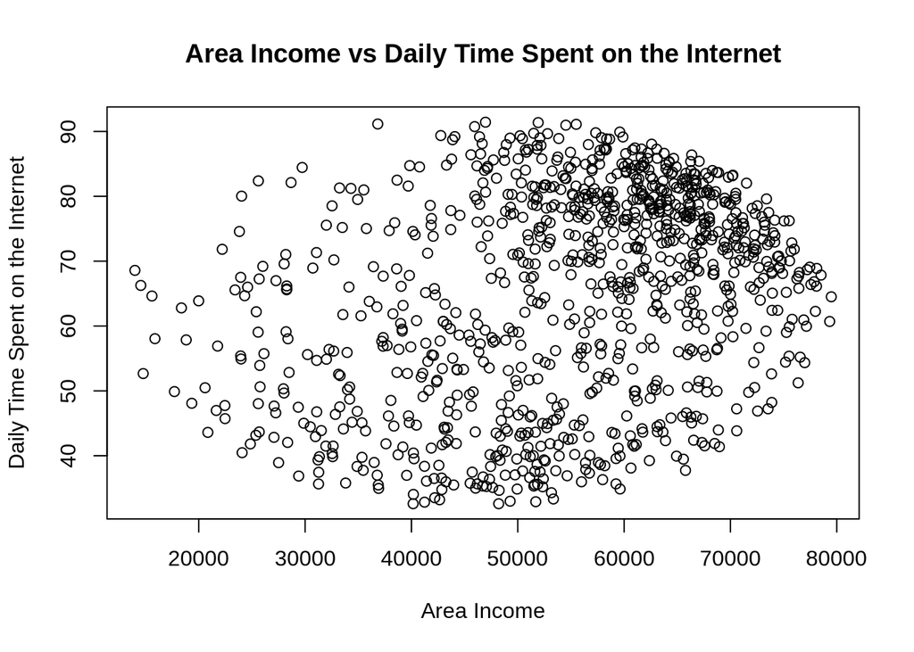

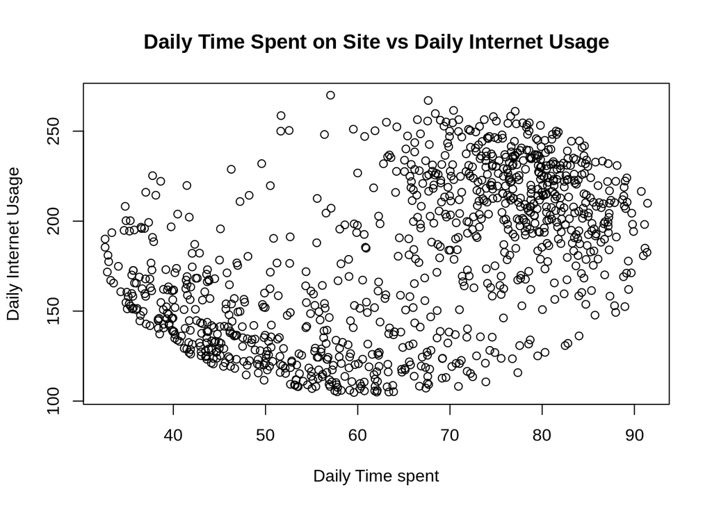

The more the Area Income the more time the user spent on the Internet and also the the more internet used

## Conclusion

I also recommend that the Client could also run Ads that are more appealing to the Male the users so that they will click on the Ads more